# R Notebook

## Introduction

I’ve created 1,000 simulations of populations undergoing different levels of sexual reproduction and analyzed the index of association over 10,000 loci. I have analyzed the index of association for 10, 25, 50, and 100 samples from each population and analyzed $\bar{r}_d$ for the data set with different levels of missing data: 1%, 5%, and 10%

## Setup

```r
library('zksimanalysis')
```

## Data retrieval

The data were downloaded from the CGRB server using rsync with the following command.

> Note: replace XXXXX with the port number. I am not writing it here for security reasons.

```
rsync --update -avz -e "ssh -p XXXXX" --exclude 'twenty_loci_results' \
kamvarz@files.cgrb.oregonstate.edu:/nfs1/BPP/Grunwald_Lab/home/kamvarz/simulation_analysis/results \
../simulation_results
```

```r
# Here we have to filter out the stored genetic data
genomic_data <- load(here::here("data", "genomic_data.rda"))
genomic_data
```

## Visualizations

```r
old_theme <- theme_set(theme_bw(base_size = 16, base_family = "Helvetica"))
old_theme <- theme_update(axis.text.x = element_text(angle = 90, vjust = 0.5))
old_theme <- theme_update(text = element_text(size = 16))
my_theme  <- theme(panel.border = element_blank()) +
  theme(panel.grid.major.x = element_blank()) +
  theme(panel.grid.major.y = element_line(color = "grey20")) +
  theme(panel.grid.minor.y = element_line(color = "grey50", linetype = 3))
asp       <- function(r) theme(aspect.ratio = r)
# The p-value for rd is best visualized on a log scale. This provides that
# the color scaling for that transformation, emphasizing smaller p-values over
# larger ones.
log_rd_color <- function(breaks = c(0.005, 0.01, 0.025, 0.05, 0.1)){
  scale_color_viridis(option = "viridis",
                      breaks = log(breaks),
                      labels = breaks)
}

# Various labels with mathematical expressions are used for the plots.
# Pre-defining them here allows us to use eval(exp) instead of re-typing the
# entire expression every time.
rd    <- quote(expression(bar(r)[d]))
rdcc  <- quote(expression(paste(bar(r)[d], " (clone-corrected)")))
prd   <- quote(expression(paste("p-value (", bar(r)[d], ")")))
prdcc <- quote(expression(paste("p-value (", bar(r)[d], " (clone-corrected))")))
E5g   <- quote(expression(paste("Genotypic evenness (", E[5][G], ")")))
E5a   <- quote(expression(paste("Mean allelic evenness (", E[5][A], ")")))
Hexp  <- quote(expression(paste("Nei's gene diversity (", H[exp], ")")))


fancy_clone_correct <- . %>%
  mutate(clone_correct = factor(clone_correct, labels = c("uncorrected", "clone-corrected")))
fancy_sample <- . %>%
  mutate(sample = forcats::lvls_revalue(sample, paste("n =", sort(unique(sample)))))
fancy_mutation_rate <- . %>%
  mutate(mutation_rate = factor(mutation_rate, labels = c("Even Mutation Rate", "Uneven Mutation Rate")))
```

Visualizations are one of the most important steps in an analysis. Here’s why. Below are the results when the mutation rate is 1e-5

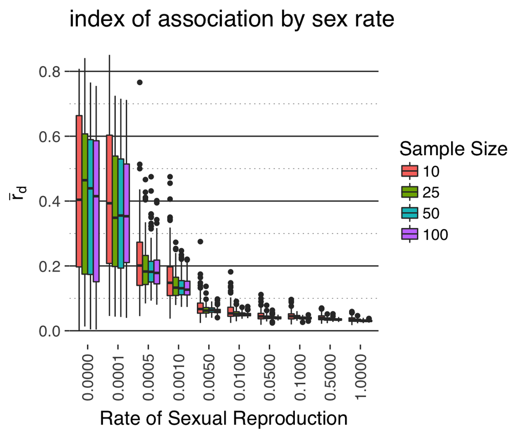

```r
missing_plot <- missing_stats %>%
  select(sexrate, rd, sample, matching, missing) %>%
  fancy_sample %>%
  mutate(missing = paste0(sprintf("%d", missing*100), "%")) %>%
  mutate(missing = factor(missing, levels = unique(missing))) %>%
  mutate(matching = ifelse(matching == "match", "ignored", "new allele")) %>%
  ggplot(aes(x = sexrate, y = rd, fill = matching)) +
  geom_violin(scale = "width", draw_quantiles = c(0.25, 0.5, 0.75)) +
  scale_fill_grey(start = 1, end = 0.5) +
  facet_grid(sample ~ missing, switch = "y") +
  scale_y_continuous(position = "right", breaks = c(0, 0.5, 1),
                     minor_breaks = c(0.25, 0.75), limits = c(NA, 1)) +
  theme(text = element_text(size = 16)) +
  theme(strip.text = element_text(size = 16, face = "bold")) +
  theme(strip.background = element_blank()) +
  my_theme +
  theme(aspect.ratio = 1/2) +
  theme(legend.position = "bottom") +
  labs(list(
    # title = "index of association across missing data",
    x = "Rate of Sexual Reproduction",
    y = eval(rd),
    fill = "Missing Data"
    ))

if (!interactive()){
  ggsave(filename = here::here("manuscript", "figure", "genomic_missing.pdf"),
       plot = missing_plot, dpi = 600, height = 6, width = 7)
}


main_rd_plot <- ggplot(original %>% select(sexrate, rd, sample),
       aes(x = sexrate, y = rd, fill = sample)) +
  geom_boxplot() +
  my_theme +
    labs(list(
    title = "index of association by sex rate",
    x = "Rate of Sexual Reproduction",
    y = eval(rd),
    fill = "Sample Size"
    ))

pval_rd_plot <- ggplot(original %>% select(sexrate, p.rD, sample),
       aes(x = sexrate, y = p.rD, fill = sample)) +
  geom_boxplot() +
  my_theme +
    labs(list(
    title = "p-value for the index of association by sex rate",
    subtitle = "out of 999 permutations",
    x = "Rate of Sexual Reproduction",
    y = eval(prd),
    fill = "Sample Size"
    ))

main_rd_plot
```

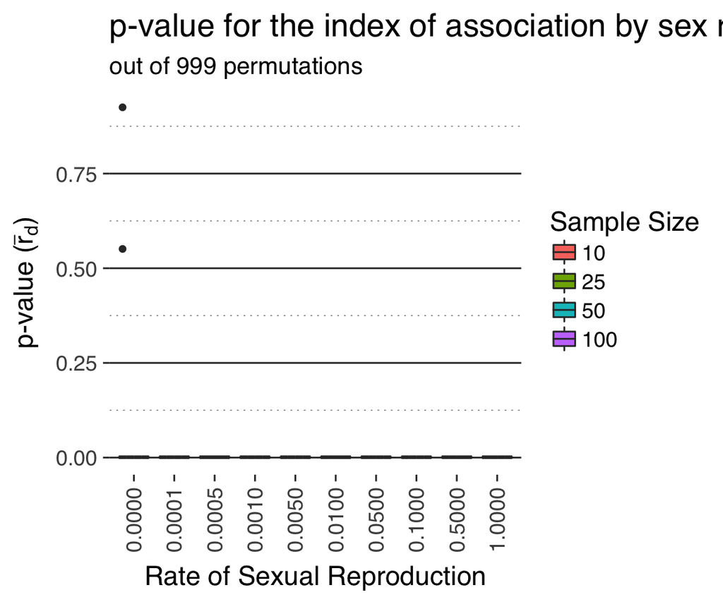

```r
pval_rd_plot
```

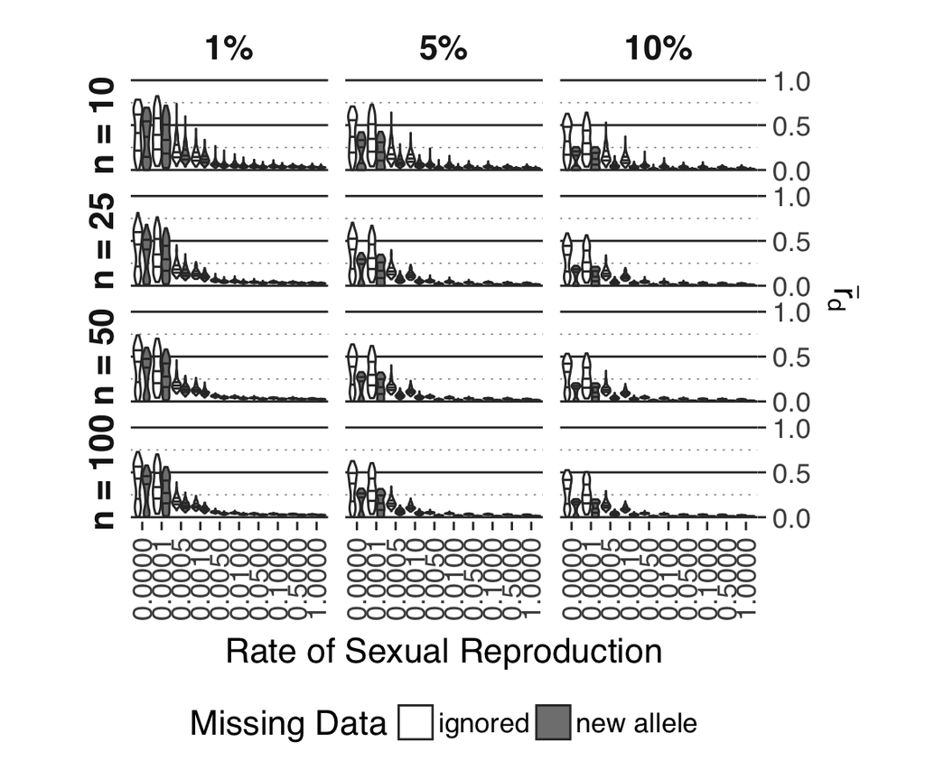

```r
missing_plot
```

This is quite weird. If you look at the value for the index of association, we can see that the minimum value is about 0.02. To get a better sense of what’s going on, we need to take a look at the value of the null distributions

```r
null_dist <- ggplot(original %>% unnest(samples) %>% select(samples, sample, sexrate),
       aes(x = samples)) +
  geom_density(aes(fill = sexrate), alpha = 0.5) +
  scale_fill_viridis(discrete = TRUE) +
  facet_wrap(~sample, ncol = 1, scale = "free_y") +
  scale_x_continuous(limits = c(-5e-4, 1e-3)) +
  ggtitle("Null distributions for the index of assocation by sample size and sex rate")
```

## Explanation of weird phenomena

```r
load(here::here("data", "genomic_rda_files/X.data.3639601.100.bpp.dir_genomic10_gen_10seed_0_sex_1.0000_gen_10000_rep_09.pop.feather.DATA.rda")) %>%
  get() %>%
  tidyr::gather(key = percent_missing, value = dataset, starts_with("dataset")) -> x

xdat <- x$dataset[[2]]
xdat
```

```
##  ||| SNPCLONE OBJECT |||||||||
##
##  || 100 genotypes,  10,000 binary SNPs, size: 1.6 Mb
##  0 (0 %) missing data
##
##  || Basic content
##    @gen: list of 100 SNPbin
##    @mlg: 100 original multilocus genotypes
##    @ploidy: ploidy of each individual  (range: 2-2)
##
##  || Optional content
##    @ind.names:  100 individual labels
##    @loc.names:  10000 locus labels
##    @chromosome: factor storing chromosomes of the SNPs
##    @position: integer storing positions of the SNPs
##    @pop: population of each individual (group size range: 100-100)
##    @strata: a data frame with 9 columns ( clone_proj, sex_proj, ind_id, mother_id, father_id, tsmrsr, ... )
##    @other: a list containing: elements without names
```

```r
load(here::here("data", "genomic_rda_files/X.data.3639601.1.grungall1.dir_genomic10_gen_10seed_0_sex_0.0000_gen_10000_rep_01.pop.feather.DATA.rda")) %>%
  get() %>%
  tidyr::gather(key = percent_missing, value = dataset, starts_with("dataset")) -> y

ydat <- y$dataset[[2]]
ydat
```

```
##  ||| SNPCLONE OBJECT |||||||||
##
##  || 100 genotypes,  10,000 binary SNPs, size: 1.6 Mb
##  0 (0 %) missing data
##
##  || Basic content
##    @gen: list of 100 SNPbin
##    @mlg: 100 original multilocus genotypes
##    @ploidy: ploidy of each individual  (range: 2-2)
##
##  || Optional content
##    @ind.names:  100 individual labels
##    @loc.names:  10000 locus labels
##    @chromosome: factor storing chromosomes of the SNPs
##    @position: integer storing positions of the SNPs
##    @pop: population of each individual (group size range: 100-100)
##    @strata: a data frame with 9 columns ( clone_proj, sex_proj, ind_id, mother_id, father_id, tsmrsr, ... )
##    @other: a list containing: elements without names
```

Now, I’ll simulate a sexual population using the `glSim()` functin from *adegenet*:

```r
set.seed(20161018)
xsim <- glSim(100, 1e4, 0, ploidy = 2) %>% as.snpclone()
xsim
```

```
##  ||| SNPCLONE OBJECT |||||||||
##
##  || 100 genotypes,  10,000 binary SNPs, size: 393.8 Kb
##  0 (0 %) missing data
##
##  || Basic content
##    @gen: list of 100 SNPbin
##    @mlg: 100 original multilocus genotypes
##    @ploidy: ploidy of each individual  (range: 2-2)
##
##  || Optional content
##    @other: a list containing: ancestral.pops
```

Now, let’s look at the values of $\bar{r}_d$:

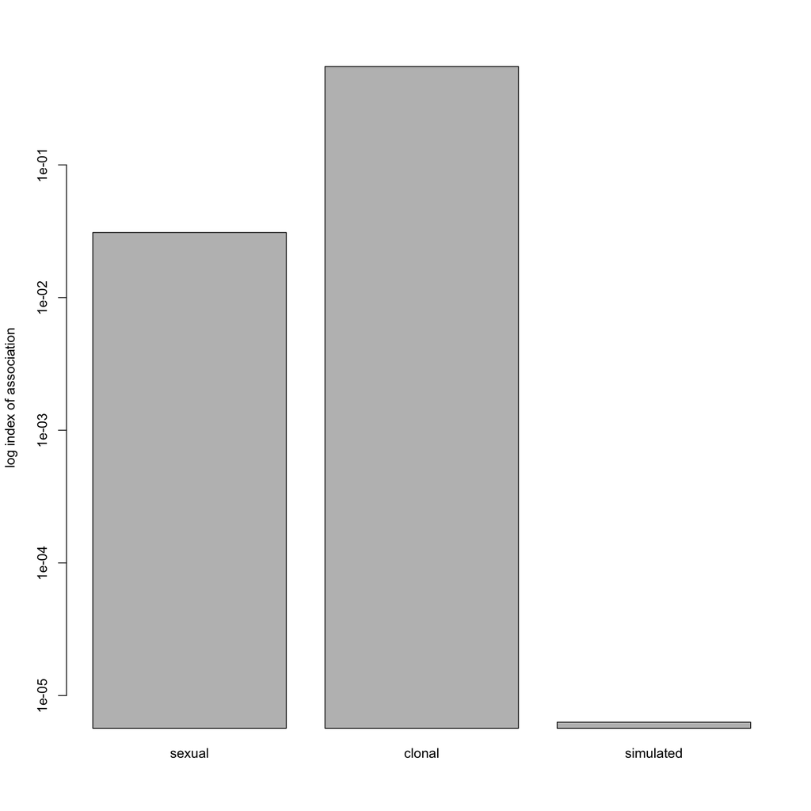

```r
barplot(c(sexual = bitwise.ia(xdat, threads = 1L),
          clonal = bitwise.ia(ydat, threads = 1L),
          simulated = bitwise.ia(xsim, threads = 1L)), log = "y", ylab = "log index of association")
```

We can clearly see that the value of $\bar{r}_d$ is different between the sexual and simulated population. What’s causing this difference? A quick look at the dendrograms produced will give us a good idea:

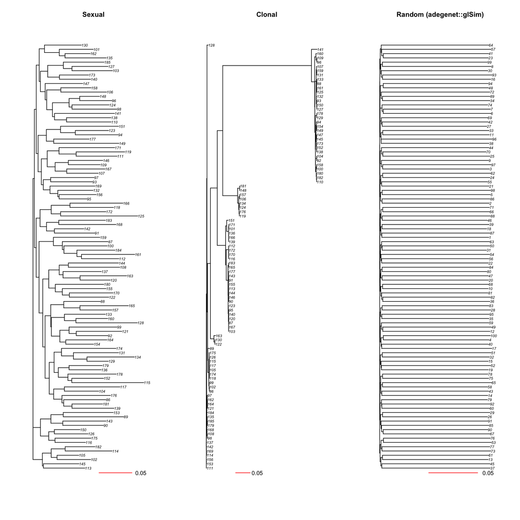

```r
library('ape')
xdat %>% bitwise.dist(threads = 1L) %>% nj() -> sexdist
ydat %>% bitwise.dist(threads = 1L) %>% nj() -> clonedist
xsim %>% bitwise.dist(threads = 1L) %>% nj() -> simdist
par(mfrow = c(1, 3))
plot(sexdist, main = "Sexual")
add.scale.bar(x = 0.1, y = -0.1, lcol = "red", length = 0.05)
plot(clonedist, main = "Clonal")
add.scale.bar(x = 0.1, y = -0.1, lcol = "red", length = 0.05)
plot(simdist,   main = "Random (adegenet::glSim)")
add.scale.bar(x = 0.05, y = -0.1, lcol = "red", length = 0.05)
```

```r
par(mfrow = c(1, 1))
```

Okay, that clears things up a little bit. The simulated population has a LOT of variance. When happens to our populations if we shuffle them?

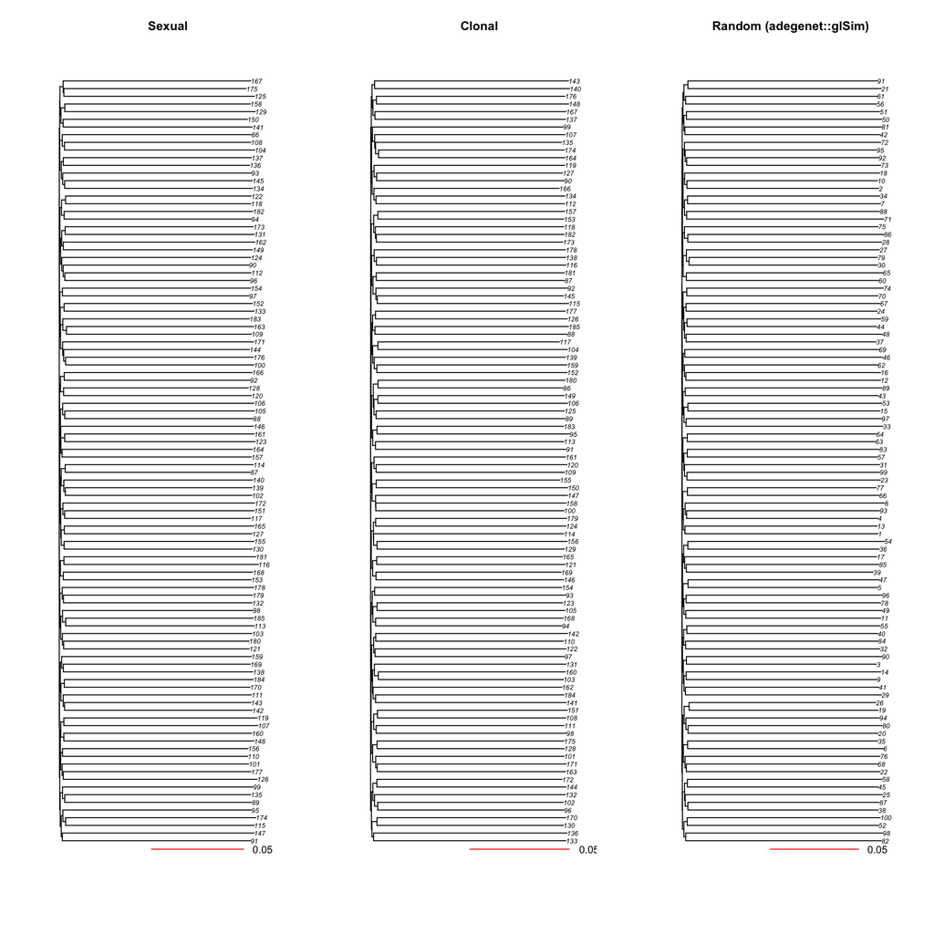

```r
xdat %>% shuffle_genlight(mat = as.matrix(.), x = ., blocksize = 1) %>% bitwise.dist(threads = 1L) %>% nj() -> sexdist
ydat %>% shuffle_genlight(mat = as.matrix(.), x = ., blocksize = 1) %>% bitwise.dist(threads = 1L) %>% nj() -> clonedist
xsim %>% shuffle_genlight(mat = as.matrix(.), x = ., blocksize = 1) %>% bitwise.dist(threads = 1L) %>% nj() -> simdist
par(mfrow = c(1, 3))
plot(sexdist, main = "Sexual")
add.scale.bar(x = 0.05, y = -0.1, lcol = "red", length = 0.05)
plot(clonedist, main = "Clonal")
add.scale.bar(x = 0.05, y = -0.1, lcol = "red", length = 0.05)
plot(simdist,   main = "Random (adegenet::glSim)")
add.scale.bar(x = 0.05, y = -0.1, lcol = "red", length = 0.05)
```

```r
par(mfrow = c(1, 1))
```

One question I still have is: what does it look like with under prinicpal component analysis. The goal of this is to find the variables that contribute to the separation of the data.

[figure not shown]

```r
xdat %>% glPca(nf = 100) -> xdat.pc
ydat %>% glPca(nf = 100) -> ydat.pc
xsim %>% glPca(nf = 100) -> xsim.pc

xdat.s <- xdat.pc$scores[, 1:2]
ydat.s <- ydat.pc$scores[, 1:2]
xsim.s <- xsim.pc$scores[, 1:2]
lims <- range(c(xdat.s, ydat.s, xsim.s))
plot(xdat.s, xlim = lims, ylim = lims, col = "red")
points(ydat.s, xlim = lims, ylim = lims, col = "blue")
points(xsim.s, xlim = lims, ylim = lims)
legend("topright", legend = c("Sexual", "Clonal", "Random (adegenet::glSim)"),
       col = c("red", "blue", "black"), pch = c(1, 1, 1))
```

### Re-analyze index of association

Since we saw all significant values for $\bar{r}_d$ based on randomly permuting linked markers, we’ll test here what happens when we randomly permute the chromosomes. This was done on the OSU CGRB cluster and downloaded here.

```r
original_redux %>%
  group_by(sexrate) %>%
  summarize(n = n()/4)
```

```
## # A tibble: 10 x 2
##    sexrate     n
##      <chr> <dbl>
##  1  0.0000   120
##  2  0.0001   120
##  3  0.0005   120
##  4  0.0010   120
##  5  0.0050   120
##  6  0.0100   120
##  7  0.0500   120
##  8  0.1000   120
##  9  0.5000   120
## 10  1.0000   120
```

```r
original_redux %>%
  group_by(sexrate, run) %>%
  summarize(n = n()/4) %>%
  spread(key = run, value = n)
```

```
## # A tibble: 10 x 25
## # Groups:   sexrate [10]
##    sexrate   `1`  `10`  `11`  `12`  `13`  `14`  `15`  `16`  `17`  `18`
##  *   <chr> <dbl> <dbl> <dbl> <dbl> <dbl> <dbl> <dbl> <dbl> <dbl> <dbl>
##  1  0.0000     5     5     5     5     5     5     5     5     5     5
##  2  0.0001     5     5     5     5     5     5     5     5     5     5
##  3  0.0005     5     5     5     5     5     5     5     5     5     5
##  4  0.0010     5     5     5     5     5     5     5     5     5     5
##  5  0.0050     5     5     5     5     5     5     5     5     5     5
##  6  0.0100     5     5     5     5     5     5     5     5     5     5
##  7  0.0500     5     5     5     5     5     5     5     5     5     5
##  8  0.1000     5     5     5     5     5     5     5     5     5     5
##  9  0.5000     5     5     5     5     5     5     5     5     5     5
## 10  1.0000     5     5     5     5     5     5     5     5     5     5
## # ... with 14 more variables: `19` <dbl>, `2` <dbl>, `20` <dbl>,
## #   `21` <dbl>, `22` <dbl>, `23` <dbl>, `24` <dbl>, `3` <dbl>, `4` <dbl>,
## #   `5` <dbl>, `6` <dbl>, `7` <dbl>, `8` <dbl>, `9` <dbl>
```

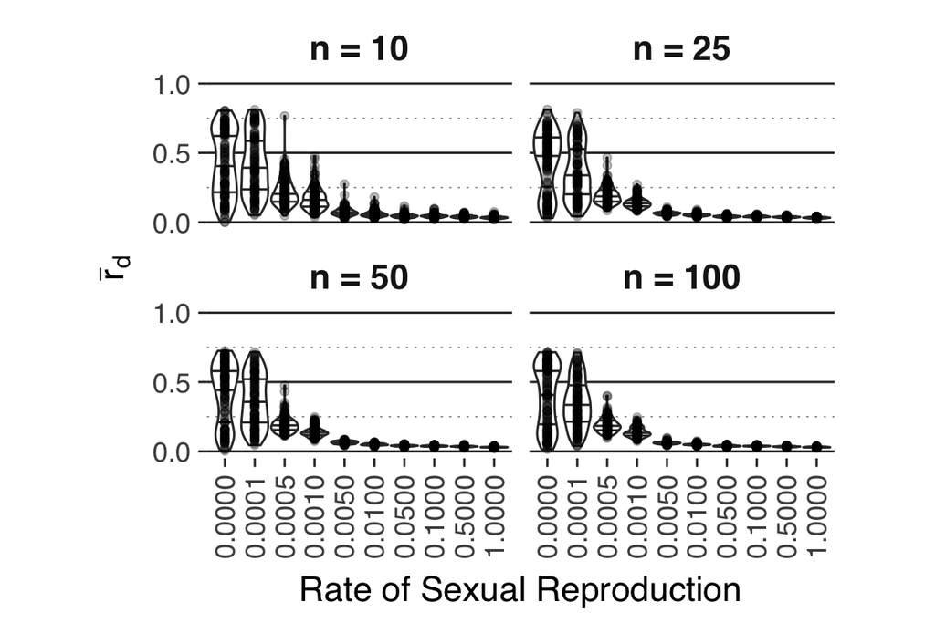

```r
corrected_rd <- original_redux %>%
  select(sexrate, rd, sample) %>%
  fancy_sample %>%
  ggplot(aes(x = sexrate, y = rd)) +
  geom_violin(scale = "width", draw_quantiles = c(0.25, 0.5, 0.75)) +
  geom_point(alpha = 0.25) +
  # geom_boxplot(outlier.color = "grey50", outlier.size = 0.5) +
  # scale_fill_grey(start = 0.5, end = 1) +
    labs(list(
    # title = "index of association by sex rate",
    x = "Rate of Sexual Reproduction",
    y = eval(rd)
    )) +
  facet_wrap(~sample) +
  my_theme +
  scale_y_continuous(breaks = c(0, 0.5, 1),
                     minor_breaks = c(0.25, 0.75),
                     limits = c(NA, 1)) +
  theme(aspect.ratio = 1/2) +
  theme(strip.background = element_blank()) +
  theme(strip.text = element_text(size = 16, face = "bold")) +
  theme(text = element_text(size = 16))
corrected_rd
```

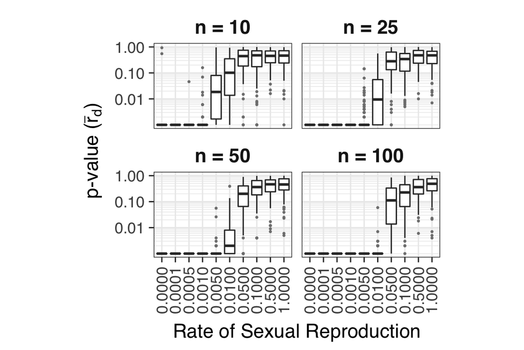

```r
if (!interactive()){
  ggsave(filename = here::here("manuscript", "figure", "genomic_rd.pdf"),
       plot = corrected_rd, dpi = 600, height = 4, width = 6)
}



correcte_rd_p <- original_redux %>%
  select(sexrate, p.rD, sample) %>%
  fancy_sample %>%
  ggplot(aes(x = sexrate, y = p.rD)) +
  geom_boxplot(outlier.color = "grey50", outlier.size = 0.5) +
  # geom_violin(scale = "width", draw_quantiles = c(0.25, 0.5, 0.75)) +
  scale_y_log10(breaks = c(0.01, 0.1, 1),
                minor_breaks = c((1:9)*0.001, (2:9)*0.01, (2:9)*0.1)) +
  # scale_fill_grey(start = 0.5, end = 1) +
    labs(list(
    # title = "p-value for the index of association by sex rate",
    # subtitle = "out of 999 permutations",
    x = "Rate of Sexual Reproduction",
    y = eval(prd)
    # fill = "Sample Size"
    )) +
  facet_wrap(~sample) +
  theme(aspect.ratio = 1.618^-1) +
  theme(strip.background = element_blank()) +
  theme(strip.text = element_text(size = 16, face = "bold")) +
  theme(text = element_text(size = 16))
correcte_rd_p
```

Now we can take a look at the null distributions by sex rate and sample size

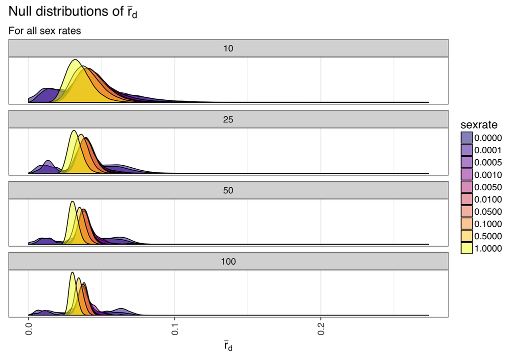

```r
no_y <- theme(axis.title.y = element_blank()) +
  theme(axis.text.y = element_blank()) +
  theme(axis.ticks.y = element_blank()) +
  theme(panel.grid.major.y = element_blank()) +
  theme(panel.grid.minor.y = element_blank())
null_dist <- original_redux %>%
  unnest(samples) %>%
  select(samples, sexrate, sample) %>%
  ggplot(aes(x = samples)) +
  geom_density(aes(fill = sexrate), alpha = 0.5) +
  scale_fill_viridis(discrete = TRUE, option = "plasma") +
  facet_wrap(~sample, ncol = 1, scale = "free_y") +
  labs(list(
    title = expression(paste("Null distributions of ", bar(r)[d])),
    subtitle = "For all sex rates",
    x = eval(rd)
  )) +
  no_y
null_dist
```

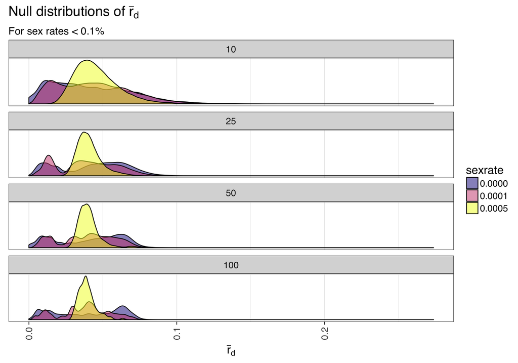

```r
# Only the most clonal of the non-random mating
clone_dist <- original_redux %>%
  unnest(samples) %>%
  select(samples, sexrate, sample) %>%
  filter(sexrate %in% c("0.0000", "0.0001", "0.0005")) %>%
  ggplot(aes(x = samples)) +
  geom_density(aes(fill = sexrate), alpha = 0.5) +
  scale_fill_viridis(discrete = TRUE, option = "plasma") +
  facet_wrap(~sample, ncol = 1, scale = "free_y") +
  labs(list(
    title = expression(paste("Null distributions of ", bar(r)[d])),
    subtitle = "For sex rates < 0.1%",
    x = eval(rd)
  )) +
  no_y
clone_dist
```

## Session Information

```r
options(width = 100)
```

```
##  setting  value
##  version  R version 3.4.1 (2017-06-30)
##  system   x86_64, darwin15.6.0
##  ui       X11
##  language (EN)
##  collate  en_US.UTF-8
##  tz       America/Chicago
##  date     2017-08-27
```

```
## Packages ------------------------------------------------------------------------------------------
```

[output not shown]

[output cut: 56 more lines]

```
##  tibble        * 1.3.3      2017-05-28 CRAN (R 3.4.0)
##  tidyr         * 0.6.3      2017-05-15 CRAN (R 3.4.0)
##  tidyverse     * 1.1.1      2017-01-27 CRAN (R 3.4.0)
##  tools           3.4.1      2017-07-07 local
##  utils         * 3.4.1      2017-07-07 local
##  vcfR          * 1.5.0      2017-05-18 cran (@1.5.0)
##  vegan           2.4-4      2017-08-24 cran (@2.4-4)
##  VGAM            1.0-4      2017-07-25 CRAN (R 3.4.1)
##  viridis       * 0.4.0      2017-03-27 CRAN (R 3.4.0)
##  viridisLite   * 0.2.0      2017-03-24 CRAN (R 3.4.0)
##  withr           2.0.0      2017-07-28 CRAN (R 3.4.1)
##  xml2            1.1.1      2017-01-24 CRAN (R 3.4.0)
##  xtable          1.8-2      2016-02-05 CRAN (R 3.4.0)
##  yaml            2.1.14     2016-11-12 CRAN (R 3.4.0)
##  zksimanalysis * 0.9.0.9000 2017-08-26 local
```